# FP - RDD: Reimers (2019) [100 Points]

ECON 474 Econometrics of Policy Evaluation

# 1 Research Design

This section is centered around understanding the research design for this paper.

## 1.1 Research Question

What is the research question of this paper?

*Hint: economists are notorious for not explicitly stating their research question in their papers.*

**Your answer:**

How does intellectual property affect the use of creative work?

## 1.2 Empirical Design

1. What is the casual technique of this paper, and why is it chosen?

**Your answer:**

RDD because of arbitrary policy date threshold.

2. Name one threat to identification.

**Your answer:**

There could be historical confounders around 1923 that affect publishing rates. But honestly, this paper has incredibly clean identification because the year 1923 was chosen in 1998.

# 2 Replication

The paper estimates the regression:

$$y_j = \delta 1\{IP =1\} + k(year_j) +
X_j \beta + \epsilon_j$$

where $j$ is the specific book title (e.g. Gone with the Wind).

The mapping of the variables in the regression to the data are:

- $y_j$
  - `ntitle` - number of in-print editions per title
  - `ntitleformat` - number of in-print editions per title for each format (e.g. hardcover, paperback, e-book)
- $1\{IP =1\}$ - `post1923` (publication year $\geq$ 1923)
- $k(year_j)$ - a third degree polynomial of `year`
- $X_j$
  - `plr` - British Public Library Demand (checkouts)
  - `prize_author` - Author is a Pulitzer Prize winner
  - `canon_title` - Book listed in Harold Bloom’s Western Canon: The Books and School of the Ages
  - `canon_author` - Author listed in Harold Bloom’s Western Canon: The Books and School of the Ages

Additionally, there is a variable `format` that lists the formats in which the book is published.

Load in the data and any necessary packages:

```r
library(haven)
library(tidyverse)
library(fixest)

df = read_dta('C:/Users/johnj/Dropbox/Julian/Academia/UIUC/Semester 11 Fall 2022/ECON474/Final Project/Reimers 2019/amazon_data.dta')
```

*Note: if you are still confused what this paper is analyzing, go to Amazon and search for the Wealth of Nations. There are **many** different versions of the same book. This is not the case for a book that has been published recently.*

## 2.1 Main Results: Table 2

The regressions in table 2 only consider `year`s that are $\geq$ -8 years before the cutoff and $\leq$ 7 years after the cutoff. All regressions cluster on the `year` of publication variable. The column specific details are:

1. outcome `ntitle` on the additional subset of `"Hardcover"` `format`s
2. outcome `ntitleformat` on the additional subset of `"Hardcover"` `format`s
3. outcome `ntitleformat` on the additional subset of `"Paperback"` `format`s
4. outcome `ntitleformat` on the additional subset of `"E-book"` `format`s

Replicate table 2 in an `etable()`. Rename all variables appropriately (recall you cannot rename the cluster variable). Specify the `fitstat` argument appropriately. Use the `extralines` argument of the `etable()` to:

1. Add any missing elements
2. Add the effect size following the papers methodology
   - *Hint: Obtain the* $delta$s *and then divide them by the **pre-cutoff** averages of the outcome variables for the **subsample that matches the regressions**.*

*Note: the coefficients on the polynomial and the intercept will be different than the paper but the rest will be the same.*

```r
fit_tab2_1 = feols(ntitle ~ post1923 + plr + prize_author + canon_title + canon_author + poly(year,3),
      data = df,
      cluster = ~ year,
      subset = ~ year >= -8 &
        year <= 7 &
        format == "Hardcover")

deltas = coef(fit_tab2_1)[2]
pre_y0 = df %>%
  filter(year %in% -8:-1 & format == "Hardcover") %>%
  pull(ntitle) %>%
  mean

fit_tab2_2_4 = list()
formats = c('Hardcover', 'Paperback', 'E-book')
for(i in 1:length(formats)){
  f = formats[i]
  fit_tab2_2_4[[i]] = feols(ntitleformat ~ post1923 + plr + prize_author + canon_title + canon_author + poly(year,3),
                         data = df,
                         cluster = ~ year,
                         subset = df$year %in% -8:7 & df$format == formats[i])

  pre_y0 = c(pre_y0,
             (df %>%
                filter(year %in% -8:-1 & format == formats[i]) %>%
                pull(ntitleformat) %>%
                mean))

  deltas = c(deltas,
             coef(fit_tab2_2_4[[i]])[2])
}

effect_size = deltas/pre_y0


etable(fit_tab2_1, fit_tab2_2_4,
       order = "!Intercept",
       fitstat = ~ n + ar2,
       extralines = list("_^Effect Size" = effect_size))
```

```
##                         fit_tab2_1  fit_tab2_2_4[[1]] fit_tab2_2_4[[2]]
## Dependent Var.:             ntitle       ntitleformat      ntitleformat
##
## post1923         -26.48*** (5.962)  -5.441*** (1.237) -15.17*** (2.959)
## plr             0.0082*** (0.0017) 0.0018*** (0.0002)  0.0028* (0.0011)
## prize_author         1.705 (2.279)    0.8978 (0.6262)    0.0244 (1.092)
## canon_title       66.02*** (10.40)    9.558** (3.005)  27.11*** (5.904)
## canon_author        10.46. (5.410)      1.767 (1.514)    5.065. (2.599)
## poly(year)1         -12.28 (33.53)    -14.21. (6.671)    -13.36 (17.13)
## poly(year)2       -34.80** (11.76)    -5.311. (2.923)   -15.83* (5.672)
## poly(year)3          4.575 (14.72)      4.238 (3.224)     4.168 (7.091)
## (Intercept)       30.06*** (2.608)  7.135*** (0.4865)  17.80*** (1.351)
## _______________ __________________ __________________ _________________
## S.E.: Clustered           by: year           by: year          by: year
## Effect Size                -0.7714            -0.6116           -0.7515
## Observations                   148                148               148
## Adj. R2                    0.76416            0.70005           0.77798
##
##                 fit_tab2_2_4[..
## Dependent Var.:    ntitleformat
##
## post1923        -2.874. (1.484)
## plr             0.0022 (0.0015)
## prize_author    0.9365 (0.6687)
## canon_title       5.161 (7.385)
## canon_author     1.189 (0.9675)
## poly(year)1       8.543 (8.729)
## poly(year)2     -4.890* (1.813)
## poly(year)3      -3.223 (3.851)
## (Intercept)     1.654. (0.8860)
## _______________ _______________
## S.E.: Clustered        by: year
## Effect Size              -2.049
## Observations                148
## Adj. R2                 0.40213
## ---
## Signif. codes: 0 '***' 0.001 '**' 0.01 '*' 0.05 '.' 0.1 ' ' 1
```

## 2.2 RDD Plot - Figure 1

Replicate Figure 1 with appropriately labelled axes and title, which uses a third-order polynomial on each side of the cutoff on the outcome `ntitle`. Do not remove the standard error from the fitted line.

*Hint: create another data frame that is aggregated at the annual level, and adjust the* `year` *variable.*

*Note: the figure will not be identical but will be close to the one in the paper.*

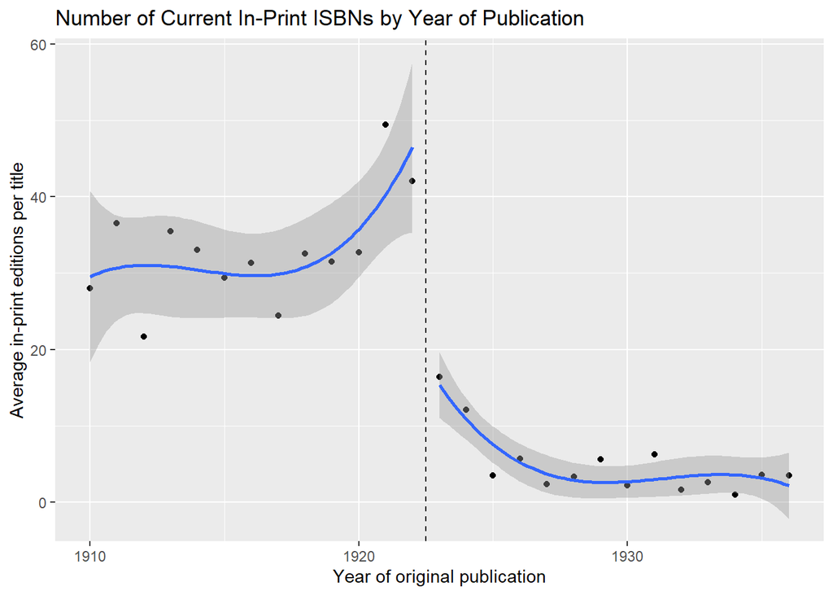

```r
df_plot = df %>%
  group_by(year) %>%
  summarise(ntitle = mean(ntitle),
            year = unique(year + 1923)) %>%
  mutate(group = year >= 1923)

ggplot(df_plot, aes(x = year, y = ntitle, group = group)) +
  geom_point() +
  geom_smooth(method = 'lm',
              formula = y ~ poly(x, 3)) +
  geom_vline(xintercept = 1922.5, linetype = 'dashed') +
  labs(x = "Year of original publication",
       y = "Average in-print editions per title",
       title = "Number of Current In-Print ISBNs by Year of Publication")
```